# Unveiling Economic Thought: A Textual Analysis of Keynes, Smith, and Ricardo

Edgar Chicurel

2024-06-05

## Hypothesis

Based on the analysis of these texts, I believe that the works of **Keynes**, **Smith**, and **Ricardo** will reveal significant differences in their economic theories and ideologies. I expect that their writings will contain distinct vocabulary and themes, which I will identify through the previous mention text mining techniques. Additionally, I anticipate that these analysis will uncover correlations between specific words and ideas that are unique to each author’s work. Through this project, I hope to deepen our understanding of the contributions these economists made to the field of economics.

### Books and Gutenberg Identifier

- *A Tract on Monetary Reform* by John Maynard Keynes **65278**
- *The Economic Consequences of the Peace* by John Maynard Keynes **15776**
- *An Inquiry into the Nature and Causes of the Wealth of Nations* by Adam Smith **3300**
- *On The Principles of Political Economy, and Taxation* by David Ricardo **33310**

## Loading Libraries and Initial Steps

Load libraries that were used for this text analysis

```r
library(tidyverse)
library(tidytext)
library(gutenbergr)
library(ggplot2)
library(scales)
library(igraph)
library(ggraph)
library(widyr)

# Set random seed for reproducibility
set.seed(12938)
```

Load books from Gutenberg Project with their respective IDs

```r
keynes <- gutenberg_download(c(65278, 15776))
smith <- gutenberg_download(3300)
ricardo <- gutenberg_download(33310)
```

## Word Frequencies

Preparation for analysis: tokenize books by word, filter stopwords and count word frequencies. Filtering of the stop words comes from list in tidytext **stop_words** using 3 different lexicons (SMART; snowball and onix)

Add some stopwords that appear in the texts:

```r
stopwords2 <- tibble(word = c("d", "s", "th", "a", "1","st","I","|","l"))
```

Do the same process for each author

### Keynes

```r
tidy_keynes <- keynes %>%
  unnest_tokens(word, text) %>%
  anti_join(stop_words) %>%
  anti_join(stopwords2)%>%
  count(word, sort = TRUE)

tidy_keynes
```

```
## # A tibble: 8,840 × 2
##    word         n
##    <chr>    <int>
##  1 germany    450
##  2 war        329
##  3 money      295
##  4 gold       281
##  5 german     260
##  6 exchange   242
##  7 currency   203
##  8 rate       199
##  9 cent       177
## 10 economic   176
## # … with 8,830 more rows
```

For Keynes, the top 10 most frequent words are “Germany”, “war”, “money”, “gold”, “German”, “exchange”, “currency”, “rate”, “cent”, and “economic”. This suggests that Keynes texts talk about Germany and war in the context of economics, particularly in relation to money, gold, exchange rates, and currencies

Plot

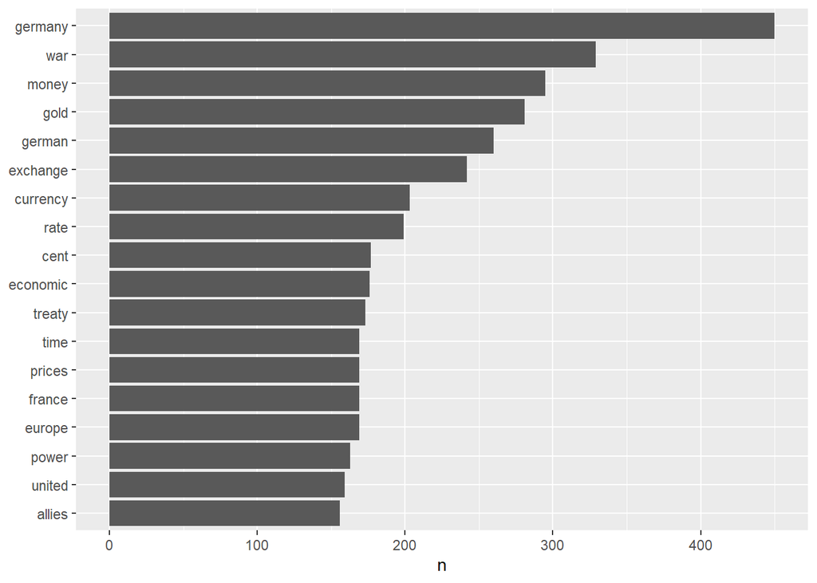

```r
tidy_keynes %>%
  filter(n > 150) %>%
  mutate(word = reorder(word, n)) %>%
  ggplot(aes(n, word)) +
  geom_col() +
  labs(y = NULL)
```

### Smith

```r
tidy_smith <- smith %>%
  unnest_tokens(word, text) %>%
  anti_join(stop_words) %>%
  anti_join(stopwords2)  %>%
  count(word, sort = TRUE)

tidy_smith
```

```
## # A tibble: 9,712 × 2
##    word         n
##    <chr>    <int>
##  1 price     1264
##  2 country   1240
##  3 labour    1011
##  4 trade      970
##  5 produce    944
##  6 quantity   797
##  7 people     777
##  8 money      770
##  9 land       720
## 10 revenue    691
## # … with 9,702 more rows
```

For Adam Smith, the top 10 most frequent words are “price”, “country”, “labour”, “trade”, “produce”, “quantity”, “people”, “money”, “land”, and “revenue”. This suggests that Smith’s writing focuses on the economics of trade, labor, and production, with a particular emphasis on prices, quantity, and revenue. Additionally, his writing also seems to touch upon the relationship between people and the economy, as well as the role of money and land in economic systems.

Plot

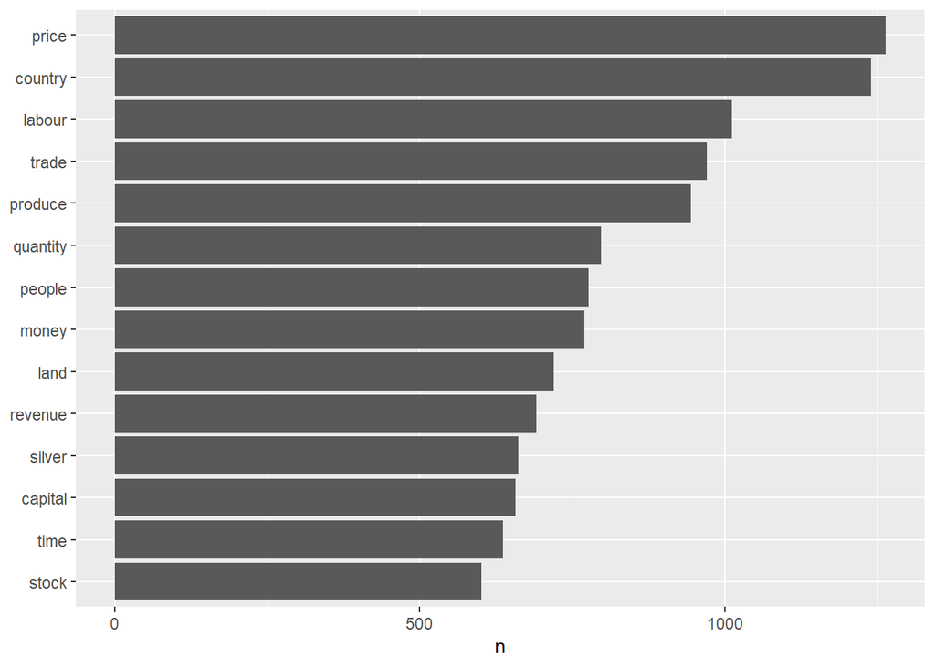

```r
tidy_smith %>%
  filter(n > 600) %>%
  mutate(word = reorder(word, n)) %>%
  ggplot(aes(n, word)) +
  geom_col() +
  labs(y = NULL)
```

### Ricardo

```r
tidy_ricardo <- ricardo %>%
  unnest_tokens(word, text) %>%
  anti_join(stop_words) %>%
  anti_join(stopwords2)  %>%
  count(word, sort = TRUE)

tidy_ricardo
```

```
## # A tibble: 4,753 × 2
##    word            n
##    <chr>       <int>
##  1 price        1032
##  2 labour        629
##  3 produce       595
##  4 capital       593
##  5 corn          565
##  6 rent          545
##  7 quantity      527
##  8 commodities   514
##  9 money         507
## 10 profits       502
## # … with 4,743 more rows
```

For David Ricardo, the top 10 most frequent words are “price”, “labour”, “produce”, “capital”, “corn”, “rent”, “quantity”, “commodities”, “money”, and “profits”. This suggests that Ricardo’s writing focuses on the economics of production, particularly in relation to labor, capital, and commodities such as corn. Additionally, his writing also seems to touch upon the role of prices, quantity, rent, money, and profits in economic systems.

Plot

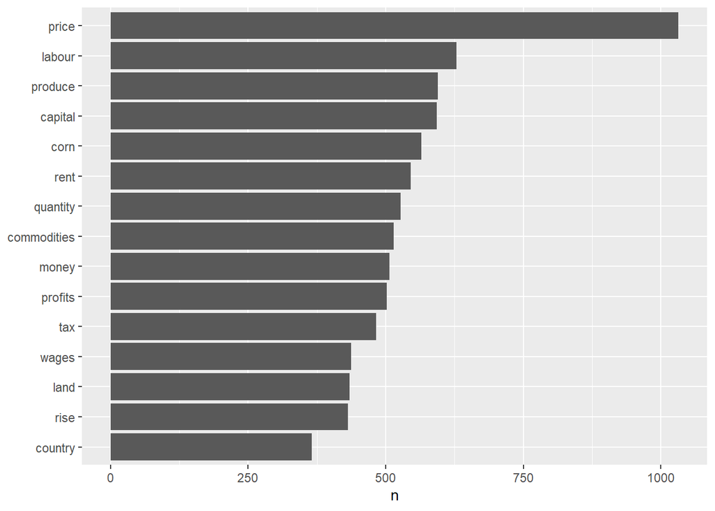

```r
tidy_ricardo %>%
  filter(n > 350) %>%
  mutate(word = reorder(word, n)) %>%
  ggplot(aes(n, word)) +
  geom_col() +
  labs(y = NULL)
```

## Crossing the authors

I will now compare **Keynes**, **Smith**, and **Ricardo** books by crossing their word frequencies, and put them in a single dataframe called `frequency`. I will use John Maynard Keynes as the reference author.

```r
frequency <- bind_rows(mutate(tidy_ricardo, author = "David Ricardo"),
                       mutate(tidy_smith, author = "Adam Smith"),
                       mutate(tidy_keynes, author = "John Maynard Keynes")) %>%
  mutate(word = str_extract(word, "[a-z]+")) %>%
  count(author, word) %>%
  group_by(author) %>%
  mutate(proportion = n / sum(n)) %>%
  select(-n) %>%
  pivot_wider(names_from = author, values_from = proportion) %>%
  pivot_longer(`David Ricardo`:`Adam Smith`,
               names_to = "author", values_to = "proportion") %>%
  anti_join(stopwords2) %>%
  anti_join(stop_words) %>%
  drop_na()

frequency
```

```
## # A tibble: 6,249 × 4
##    word       `John Maynard Keynes` author        proportion
##    <chr>                      <dbl> <chr>              <dbl>
##  1 abandon                 0.000113 David Ricardo   0.000210
##  2 abandon                 0.000113 Adam Smith      0.000103
##  3 abandoned               0.000113 David Ricardo   0.000210
##  4 abandoned               0.000113 Adam Smith      0.000103
##  5 abandoning              0.000113 Adam Smith      0.000103
##  6 abated                  0.000113 Adam Smith      0.000103
##  7 abatement               0.000113 David Ricardo   0.000210
##  8 abatement               0.000113 Adam Smith      0.000103
##  9 ability                 0.000113 David Ricardo   0.000210
## 10 ability                 0.000113 Adam Smith      0.000103
## # … with 6,239 more rows
```

Can observe the proportion of times a word is used by each author and compare them between each other.

Plot to visualize it better.

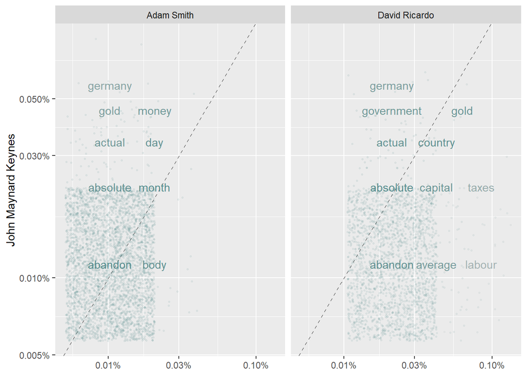

```r
ggplot(frequency, aes(x = proportion, y = `John Maynard Keynes`,
                      color = abs(`John Maynard Keynes` - proportion))) +
  geom_abline(color = "gray40", lty = 2) +
  geom_jitter(alpha = 0.1, size = 0.5, width = 0.3, height = 0.3) +
  geom_text(aes(label = word), check_overlap = TRUE, vjust = 0.5) +
  scale_x_log10(labels = percent_format()) +
  scale_y_log10(labels = percent_format()) +
  scale_color_gradient(limits = c(0, 0.001),
                       low = "darkslategray4", high = "gray75") +
  facet_wrap(~author, ncol = 2) +
  theme(legend.position="none") +
  labs(y = "John Maynard Keynes", x = NULL)
```

In the first graph (Smith with Keynes) it can be observed that words like gold, money, Germany, actual and day appear with a high frequency in both texts but appear more in Keynes literature than in Smith. Words like month, abandon and body appear relatively similar in both texts.

## Correlations

I will now use the Pearson Correlation Coefficient to measure correlations.

**John Maynard Keynes and Adam Smith**

```r
cor.test(data = frequency[frequency$author == "Adam Smith",],
         ~ proportion + `John Maynard Keynes`)
```

```
##
##  Pearson's product-moment correlation
##
## data:  proportion and John Maynard Keynes
## t = 7.6852, df = 3799, p-value = 1.932e-14
## alternative hypothesis: true correlation is not equal to 0
## 95 percent confidence interval:
##  0.0922994 0.1549119
## sample estimates:
##       cor
## 0.1237288
```

**John Maynard Keynes and David Ricardo**

```r
cor.test(data = frequency[frequency$author == "David Ricardo",],
         ~ proportion + `John Maynard Keynes`)
```

```
##
##  Pearson's product-moment correlation
##
## data:  proportion and John Maynard Keynes
## t = 9.1589, df = 2446, p-value < 2.2e-16
## alternative hypothesis: true correlation is not equal to 0
## 95 percent confidence interval:
##  0.1435114 0.2201221
## sample estimates:
##       cor
## 0.1820931
```

These correlation coefficients suggest a weak positive correlation between Keynes and Ricardo, and an even weaker positive correlation between Keynes and Smith. However these authors had different perspectives in economics and the texts used for the analysis also affect the similarity between them.

## TF-IDF

In the next Section I conducted a **TF-IDF** analysis to look at words that make the texts distinctive.

### Joinning Dataframes

I joined the authors dataframes into one global dataframe with all the books and adding a new column to differentiate between authors.

```r
tidy_ricardo = tidy_ricardo %>%
  mutate(
    author = "David Ricardo"
  )

tidy_smith = tidy_smith %>%
  mutate(
    author = "Adam Smith"
  )

tidy_keynes = tidy_keynes %>%
  mutate(
    author = "John Maynard Keynes"
  )

economists = tidy_keynes %>%
  rbind(tidy_ricardo, tidy_smith)
```

### TF-IDF Computation

I created a column with the total of words by each author, then added a term_frequency column with the word/total and finally using the function **bind_tf_idf** from the **tidytext** package the **TF-IDF** for each author.

```r
total_economists <- economists %>%
  group_by(author) %>%
  summarize(total = sum(n))

economists_words <- economists %>%
  left_join(total_economists) %>%
    mutate(term_frequency = n/total)

economists_tf_idf <- economists_words %>%
  bind_tf_idf(word, author, n)%>%
  select(-total) %>%
  arrange(desc(tf_idf))

economists_tf_idf
```

```
## # A tibble: 23,305 × 7
##    word          n author              term_frequency      tf   idf  tf_idf
##    <chr>     <int> <chr>                        <dbl>   <dbl> <dbl>   <dbl>
##  1 corn        565 David Ricardo              0.0130  0.0130  0.405 0.00528
##  2 economic    176 John Maynard Keynes        0.00349 0.00349 1.10  0.00384
##  3 1919         97 John Maynard Keynes        0.00193 0.00193 1.10  0.00212
##  4 german      260 John Maynard Keynes        0.00516 0.00516 0.405 0.00209
##  5 germany's    95 John Maynard Keynes        0.00189 0.00189 1.10  0.00207
##  6 4_l          73 David Ricardo              0.00168 0.00168 1.10  0.00185
##  7 100_l        69 David Ricardo              0.00159 0.00159 1.10  0.00175
##  8 1922         72 John Maynard Keynes        0.00143 0.00143 1.10  0.00157
##  9 inflation    66 John Maynard Keynes        0.00131 0.00131 1.10  0.00144
## 10 1923         64 John Maynard Keynes        0.00127 0.00127 1.10  0.00140
## # … with 23,295 more rows
```

### Plot TF-IDF

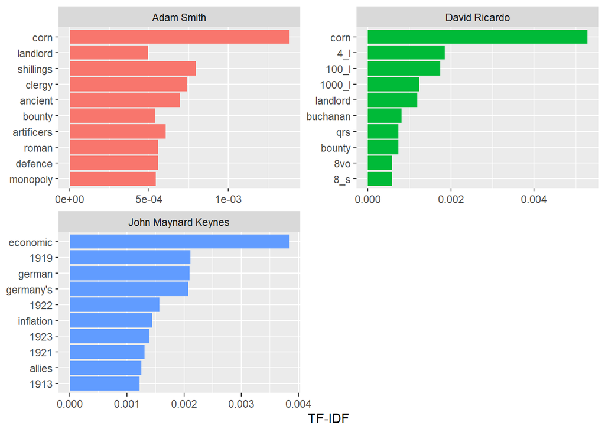

```r
economists_tf_idf %>%
  group_by(author) %>%
  arrange(desc(tf_idf)) %>%
  slice_head(n = 10) %>%
  ggplot(aes(reorder(word, tf_idf), tf_idf, fill = author)) +
  geom_col(show.legend = FALSE) +
  labs(x = NULL, y = "TF-IDF") +
  coord_flip() +
  facet_wrap(~author, ncol = 2, scales = "free")
```

There are a lot of unconvenient words which make the analysis a little bit clunky so in the next part going to fiter them and make the analysis again without these words.

### Filtering of unconvenient word

```r
economists_stopwords <- tibble(word = c("d", "s", "th", "a", "1","st","I","8vo", "8_s","4_I" ,"1000_I","100_I","1923","1922","1921","1919","1913","1920","4_l","100_l","1000_l","10_s","qrs","720_l","3_l","50_l","10,000_l","6_d","2000_l","1914","1918","pre","_r_","_k_","_n_","_k","2","0","8","4","6", "5", "4", "vol", "180", "170", "ii", "10"))


total_economists <- economists %>%
  group_by(author) %>%
  summarize(total = sum(n))

economists_words <- economists %>%
  left_join(total_economists) %>%
    mutate(term_frequency = n/total)

economists_tf_idf <- economists_words %>%
  bind_tf_idf(word, author, n)%>%
  select(-total) %>%
  anti_join(economists_stopwords, by = "word") %>%
  arrange(desc(tf_idf))
```

### Plot Without Stopwords

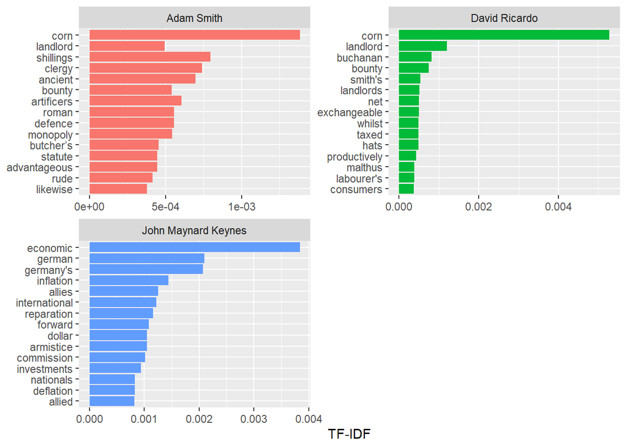

```r
economists_tf_idf %>%
  anti_join(economists_stopwords, by = "word") %>%
  group_by(author) %>%
  arrange(desc(tf_idf)) %>%
  slice_head(n = 15) %>%
  ggplot(aes(reorder(word, tf_idf), tf_idf, fill = author)) +
  geom_col(show.legend = FALSE) +
  labs(x = NULL, y = "TF-IDF") +
  coord_flip() +
  facet_wrap(~author, ncol = 2, scales = "free")
```

Based on the TF-IDF analysis we can make some general observations about the topics and themes present in the texts by Smith, Keynes, and Ricardo.

For Adam Smith, the top keywords are related to land, agriculture, and government policies related to production and trade. This is in line with Smith’s focus on the importance of free markets and competition in driving economic growth.

For Keynes, the top keywords are related to the economic and political issues surrounding World War I and its aftermath, particularly in relation to Germany, inflation, and international relations. This reflects Keynes’ view that government intervention in the economy can be necessary to address economic crises.

For Ricardo, the top keywords are related to land, agriculture, and the relationships between landlords, laborers, and consumers. This is consistent with Ricardo’s focus on the role of rent, wages, and profits in economic systems.

## N-grams

Now, in this next section an N-grams analysis is done. First 2 functions are created in order to make a bigrams (2 words) analysis.

The **count_bigrams** function:

1. Splits the text into individual words and then group them into bigrams.
2. Separates the splited words from bigrams into separate columns for each word.
3. Filters to remove any stop words from the bigrams.
4. Counts the frequency of each unique bigram and sorts the results in descending order.
5. Resulting output is a data frame with columns for each word in the bigram and a frequency count.

The **visualize_bigrams** function:

Takes the output from the count_bigrams function as input and creates a graph to visualize the relationships between the bigrams.

```r
count_bigrams <- function(dataset) {
  dataset %>%
    unnest_tokens(bigram, text, token = "ngrams", n = 2) %>%
    separate(bigram, c("word1", "word2"), sep = " ") %>%
    filter(!word1 %in% stop_words$word,
           !word2 %in% stop_words$word) %>%
    count(word1, word2, sort = TRUE)
}

visualize_bigrams <- function(bigrams) {
  set.seed(2016)
  a <- grid::arrow(type = "closed", length = unit(.15, "inches"))

  bigrams %>%
    graph_from_data_frame() %>%
    ggraph(layout = "fr") +
    geom_edge_link(aes(edge_alpha = n), show.legend = FALSE, arrow = a) +
    geom_node_point(color = "lightblue", size = 5) +
    geom_node_text(aes(label = name), vjust = 1, hjust = 1) +
    theme_void()
}
```

**Keynes bigrams**

```r
keynes_bigrams <- keynes %>%
  count_bigrams() %>%
    drop_na()

keynes_bigrams
```

```
## # A tibble: 10,970 × 3
##    word1      word2          n
##    <chr>      <chr>      <int>
##  1 purchasing power         91
##  2 pre        war           82
##  3 reparation commission    46
##  4 price      level         44
##  5 power      parity        41
##  6 bank       rate          33
##  7 note       issue         29
##  8 gold       standard      28
##  9 german     government    27
## 10 united     kingdom       25
## # … with 10,960 more rows
```

Based on these results, we can see that Keynes’ writings contain a number of bigrams related to economic concepts and policy, including “purchasing power,” “reparation commission,” “price level,” and “power parity.” The presence of bigrams related to pre-war and post-war periods, such as “pre-war” and “reparation commission,” suggest that Keynes was writing in the context of a changing economic and political landscape. Additionally, the presence of bigrams related to gold standard and bank rate suggest that Keynes was concerned with monetary policy and exchange rates.

**Smith bigrams**

```r
smith_bigrams <- smith %>%
  count_bigrams() %>%
    drop_na()

smith_bigrams
```

```
## # A tibble: 14,144 × 3
##    word1      word2       n
##    <chr>      <chr>   <int>
##  1 annual     produce   149
##  2 foreign    trade     102
##  3 money      price      89
##  4 home       market     85
##  5 rude       produce    75
##  6 0          0          65
##  7 productive labour     60
##  8 surplus    produce    60
##  9 thousand   pounds     60
## 10 east       indies     56
## # … with 14,134 more rows
```

These results indicate that Adam Smith’s writings frequently reference economic concepts related to trade, production, and labor. The most frequent bigram in Smith’s writings is “annual produce,” which may refer to the total output of goods and services in an economy. Other frequent bigrams, such as “foreign trade” and “home market,” suggest that Smith was concerned with international trade and the domestic market. Bigrams related to money and prices, such as “money price” and “thousand pounds,” suggest that Smith was also interested in monetary policy and exchange rates. The mention of the “East Indies” may also indicate a focus on trade with Asia.

**Ricardo Bigrams**

```r
ricardo_bigrams <- ricardo %>%
  count_bigrams() %>%
    drop_na()

ricardo_bigrams
```

```
## # A tibble: 5,584 × 3
##    word1    word2        n
##    <chr>    <chr>    <int>
##  1 raw      produce    152
##  2 natural  price       98
##  3 adam     smith       97
##  4 market   price       52
##  5 money    price       37
##  6 precious metals      36
##  7 foreign  trade       33
##  8 capital  employed    31
##  9 fixed    capital     27
## 10 dr       smith       26
## # … with 5,574 more rows
```

These results suggest that David Ricardo’s writings frequently reference economic concepts related to production, prices, and trade. The most frequent bigram in Ricardo’s writings is “raw produce,” which may refer to the output of natural resources and agricultural goods.The presence of bigrams related to prices, such as “natural price” and “market price,” suggest that Ricardo was interested in theories of value and pricing. The mention of Adam Smith, one of Ricardo’s predecessors and influences, also suggests that Ricardo’s writings are in dialogue with the economic ideas of his time.Finally, the mention of “precious metals” and “foreign trade” suggest that Ricardo was interested in international trade and monetary policy. The presence of bigrams related to capital, such as “capital employed” and “fixed capital,” suggest that Ricardo also considered issues related to investment and capital accumulation.

### Visualize Bigrams

**Keynes**

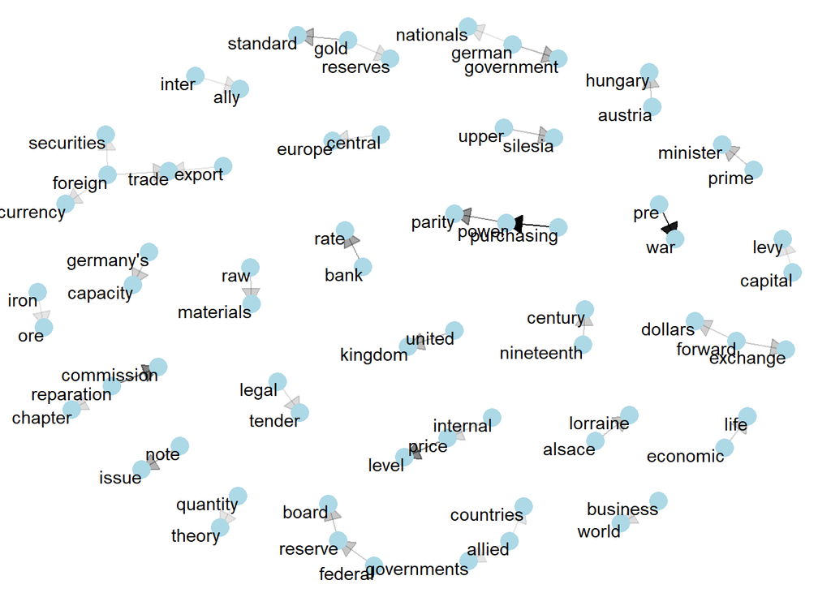

```r
keynes_bigrams %>%
  filter(n > 10,
         !str_detect(word1, "\\d"),
         !str_detect(word2, "\\d")) %>%
  visualize_bigrams()
```

We can observe more clearly all the economic concepts and institutions how they are related: For example: **federal reserve board** or **purchasing power parity**. There is a clear appearance of politic institutions in Germany and the USA with a mix of economic terms and theories.

**Smith**

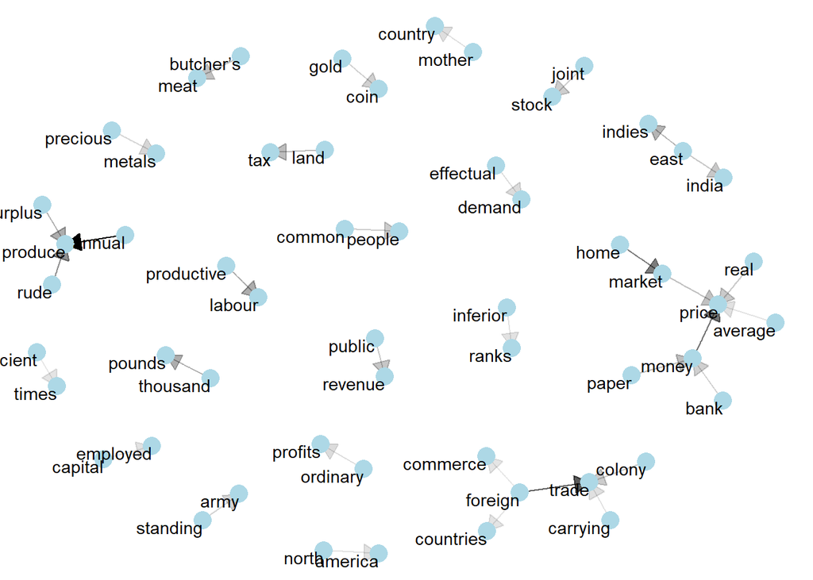

```r
smith_bigrams %>%
  filter(n > 30,
         !str_detect(word1, "\\d"),
         !str_detect(word2, "\\d")) %>%
  visualize_bigrams()
```

Here we can see how the ideas are more in groups like for example the term **trade** appears many times with **carrying**, **colony**and **foreign**. Also **money** and **produce** can be interpreted as central nodes which goes in line to what I have been saying about Adam Smith ideas of international trade, money and production.

**Ricardo**

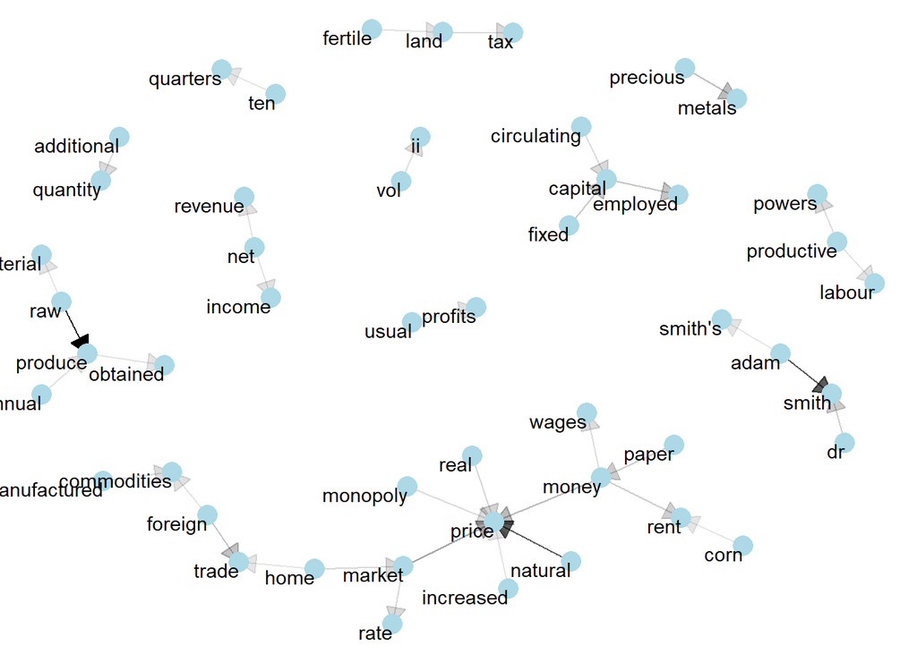

```r
 ricardo_bigrams %>%
  filter(n > 10,
         !str_detect(word1, "\\d"),
         !str_detect(word2, "\\d")) %>%
  visualize_bigrams()
```

For Ricardo, it can be seen that **price** is the most related word which goes in line with the idea I have been saying about his theories of value and pricing. Also it can be observed the mention of **Adam Smith** inside his texts and finally the idea of value can be interpreted with the **capital** and **produce** words.

## Words Contained in Lines

### Separate in Lines and Pairwise Count

**Keynes**

```r
keynes_section_words <- keynes %>%
  mutate(section = row_number() %/% 10) %>%
  filter(section > 0) %>%
  unnest_tokens(word, text) %>%
  filter(!word %in% stop_words$word) %>%
  filter(!word %in% stopwords2$word) %>%
  anti_join(economists_stopwords)

keynes_section_words
```

```
## # A tibble: 49,190 × 3
##    gutenberg_id section word
##           <int>   <dbl> <chr>
##  1        15776       1 preface
##  2        15776       2 writer
##  3        15776       2 book
##  4        15776       2 temporarily
##  5        15776       2 attached
##  6        15776       2 british
##  7        15776       2 treasury
##  8        15776       2 war
##  9        15776       2 official
## 10        15776       2 representative
## # … with 49,180 more rows
```

Using the function pairwise count to count the # of times a word and another word appear together.

**Keynes Count**

```r
keynes_word_pairs <- keynes_section_words %>%
  pairwise_count(word, section, sort = TRUE)

keynes_word_pairs
```

```
## # A tibble: 1,184,544 × 3
##    item1      item2          n
##    <chr>      <chr>      <dbl>
##  1 germany    war           89
##  2 war        germany       89
##  3 germany    german        82
##  4 german     germany       82
##  5 allies     germany       75
##  6 germany    allies        75
##  7 purchasing power         74
##  8 power      purchasing    74
##  9 germany    treaty        66
## 10 treaty     germany       66
## # … with 1,184,534 more rows
```

**Smith**

```r
smith_section_words <- smith %>%
  mutate(section = row_number() %/% 10) %>%
  filter(section > 0) %>%
  unnest_tokens(word, text) %>%
  filter(!word %in% stop_words$word) %>%
  filter(!word %in% stopwords2$word) %>%
  anti_join(economists_stopwords)

smith_section_words
```

```
## # A tibble: 129,159 × 3
##    gutenberg_id section word
##           <int>   <dbl> <chr>
##  1         3300       1 contents
##  2         3300       1 introduction
##  3         3300       1 plan
##  4         3300       1 book
##  5         3300       1 improvement
##  6         3300       1 productive
##  7         3300       1 powers
##  8         3300       1 labour
##  9         3300       1 produce
## 10         3300       1 naturally
## # … with 129,149 more rows
```

**Smith Count**

```r
smith_word_pairs <- smith_section_words %>%
  pairwise_count(word, section, sort = TRUE)

smith_word_pairs
```

```
## # A tibble: 1,982,406 × 3
##    item1   item2       n
##    <chr>   <chr>   <dbl>
##  1 silver  gold      245
##  2 gold    silver    245
##  3 land    produce   230
##  4 produce land      230
##  5 country produce   218
##  6 produce country   218
##  7 produce labour    216
##  8 labour  produce   216
##  9 price   market    200
## 10 market  price     200
## # … with 1,982,396 more rows
```

For Smith, we see a focus on the importance of land and the production of goods in a country, as well as the relationship between market price and the quantity of labor and trade. This is consistent with Smith’s emphasis on the role of markets in driving economic growth and the importance of factors of production like land and labor.

**Ricardo**

```r
ricardo_section_words <- ricardo %>%
  mutate(section = row_number() %/% 10) %>%
  filter(section > 0) %>%
  unnest_tokens(word, text) %>%
  filter(!word %in% stop_words$word) %>%
  filter(!word %in% stopwords2$word) %>%
  anti_join(economists_stopwords)

ricardo_section_words
```

```
## # A tibble: 42,502 × 3
##    gutenberg_id section word
##           <int>   <dbl> <chr>
##  1        33310       1 principles
##  2        33310       1 political
##  3        33310       1 economy
##  4        33310       2 taxation
##  5        33310       2 david
##  6        33310       2 ricardo
##  7        33310       2 esq
##  8        33310       2 london
##  9        33310       2 john
## 10        33310       2 murray
## # … with 42,492 more rows
```

**Ricardo Count**

```r
ricardo_word_pairs <- ricardo_section_words %>%
  pairwise_count(word, section, sort = TRUE)

ricardo_word_pairs
```

```
## # A tibble: 590,612 × 3
##    item1       item2           n
##    <chr>       <chr>       <dbl>
##  1 price       corn          204
##  2 corn        price         204
##  3 price       produce       186
##  4 produce     price         186
##  5 rise        price         184
##  6 price       rise          184
##  7 price       commodities   181
##  8 commodities price         181
##  9 price       labour        173
## 10 labour      price         173
## # … with 590,602 more rows
```

In general, the n-gram analysis allows us to identify specific words and phrases that are frequently used by each economist, giving us a better understanding of their areas of focus and their key ideas.

### Correlating pairs of words

A better measure taking into account the number of times the words appear is **correlation** which indicates the frequency of words appearing together in comparison to their frequency of appearing separately.

To evaluate this correlation, I used the **Phi coefficient**, which is comparable to the **Pearson Correlation**. The **Phi coefficient** determines the likelihood of two words appearing together in a corpus by considering the individual probabilities of each word appearing alone.

**Keynes**

```r
keynes_word_cors <- keynes_section_words %>%
  group_by(word) %>%
  filter(n() >= 20) %>%
  pairwise_cor(word, section, sort = TRUE)

keynes_word_cors
```

```
## # A tibble: 242,556 × 3
##    item1      item2      correlation
##    <chr>      <chr>            <dbl>
##  1 silesia    upper            0.953
##  2 upper      silesia          0.953
##  3 board      federal          0.898
##  4 federal    board            0.898
##  5 lorraine   alsace           0.884
##  6 alsace     lorraine         0.884
##  7 minister   prime            0.796
##  8 prime      minister         0.796
##  9 nineteenth century          0.771
## 10 century    nineteenth       0.771
## # … with 242,546 more rows
```

The pair “upper silesia” has the highest correlation coefficient of 0.9527372, suggesting that these two terms appear together very frequently in the analyzed text. Other pairs with high correlation coefficients include “federal board” (0.8984791), “alsace lorraine” (0.8840521), and “prime minister” (0.7959321). These pairs of words might represent specific concepts or events that were frequently discussed in the text. It can also be observed some **economic terms** like “power purschasing” and **geopolitical issues** like “austria hungary”.

**Smith**

```r
smith_word_cors <- smith_section_words %>%
  group_by(word) %>%
  filter(n() >= 20) %>%
  pairwise_cor(word, section, sort = TRUE)

smith_word_cors
```

```
## # A tibble: 1,626,900 × 3
##    item1     item2     correlation
##    <chr>     <chr>           <dbl>
##  1 butcher’s meat            0.920
##  2 meat      butcher’s       0.920
##  3 forts     garrisons       0.832
##  4 garrisons forts           0.832
##  5 answering demands         0.722
##  6 demands   answering       0.722
##  7 silver    gold            0.700
##  8 gold      silver          0.700
##  9 barrel    herrings        0.686
## 10 herrings  barrel          0.686
## # … with 1,626,890 more rows
```

For Smith, the pairs with the highest correlation seem to be related to **specific goods**, such as “butcher’s meat”, “forts garrisons”, and “barrel herrings”. Other pairs include “creditor debtor” and “receipts receipt”, which are related to **financial concepts.**

**Ricardo**

```r
ricardo_word_cors <- ricardo_section_words %>%
  group_by(word) %>%
  filter(n() >= 20) %>%
  pairwise_cor(word, section, sort = TRUE)

ricardo_word_cors
```

```
## # A tibble: 142,506 × 3
##    item1       item2       correlation
##    <chr>       <chr>             <dbl>
##  1 adam        smith             0.820
##  2 smith       adam              0.820
##  3 precious    metals            0.768
##  4 metals      precious          0.768
##  5 fish        game              0.689
##  6 game        fish              0.689
##  7 net         gross             0.567
##  8 gross       net               0.567
##  9 fixed       circulating       0.548
## 10 circulating fixed             0.548
## # … with 142,496 more rows
```

The correlations found in the analysis of Ricardo’s texts suggest that he frequently discussed topics related to **economics** and **commerce**, as well as the work of **Adam Smith**. Additionally, Ricardo seems to have shown interest in **precious metals**, **fish** and **game**, as well as concepts such as net and gross, fixed and circulating capital, and maintenance funds. Finally, it appears that Ricardo also had a particular focus on **Portugal**, discussing topics such as wine and cloth in relation to the country

## Plots of Correlations

### Plotting by word

To better show our analysis, I filtered by relevant words and plot it

**Keynes**

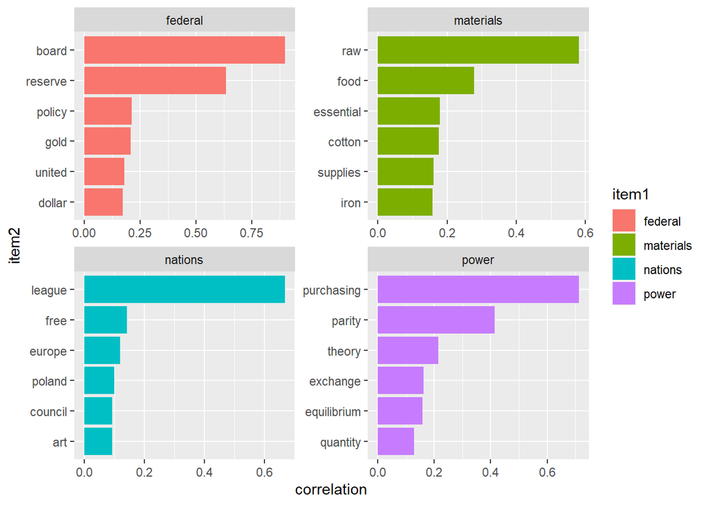

```r
keynes_word_cors %>%
  filter(item1 %in% c("federal", "power", "nations", "materials")) %>%
  group_by(item1) %>%
  slice_max(correlation, n = 6) %>%
  ungroup() %>%
  mutate(item2 = reorder(item2, correlation)) %>%
  ggplot(aes(item2, correlation, fill=item1)) +
  geom_bar(stat = "identity") +
  facet_wrap(~ item1, scales = "free") +
  coord_flip()
```

In this graph, the correlation with specific words can be observed. In the *materials* section probably it has something to do with examples Keynes gives in his book and uses those materials. *Nations* and *federal* are both words which relate to other politic topics and *power* with more general economic terms.

**Smith**

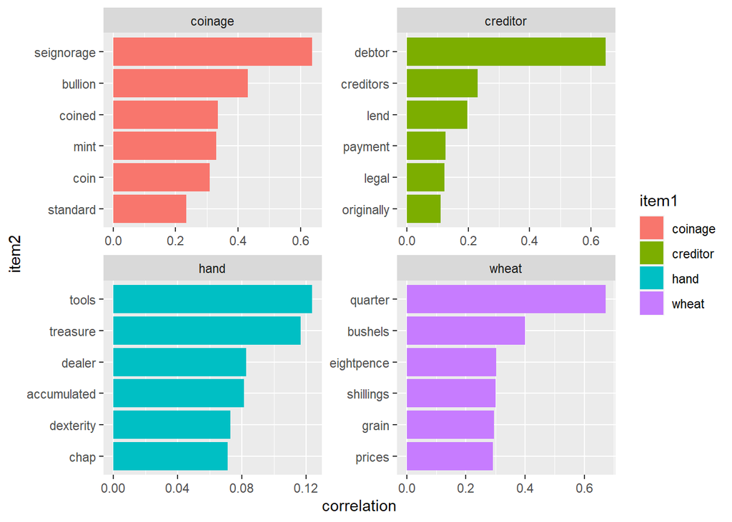

```r
smith_word_cors %>%
  filter(item1 %in% c("wheat", "creditor", "coinage", "hand")) %>%
  group_by(item1) %>%
  slice_max(correlation, n = 6) %>%
  ungroup() %>%
  mutate(item2 = reorder(item2, correlation)) %>%
  ggplot(aes(item2, correlation, fill=item1)) +
  geom_bar(stat = "identity") +
  facet_wrap(~ item1, scales = "free") +
  coord_flip()
```

In this graph, there are two type of words that relate to economic terms: *coinage* and *creditor* while *hand* relates more with characteristics of the labor force and human work. Finally, *wheat* probably appears a lot as an example of a product and it is related with money, prices and quantities.

**Ricardo**

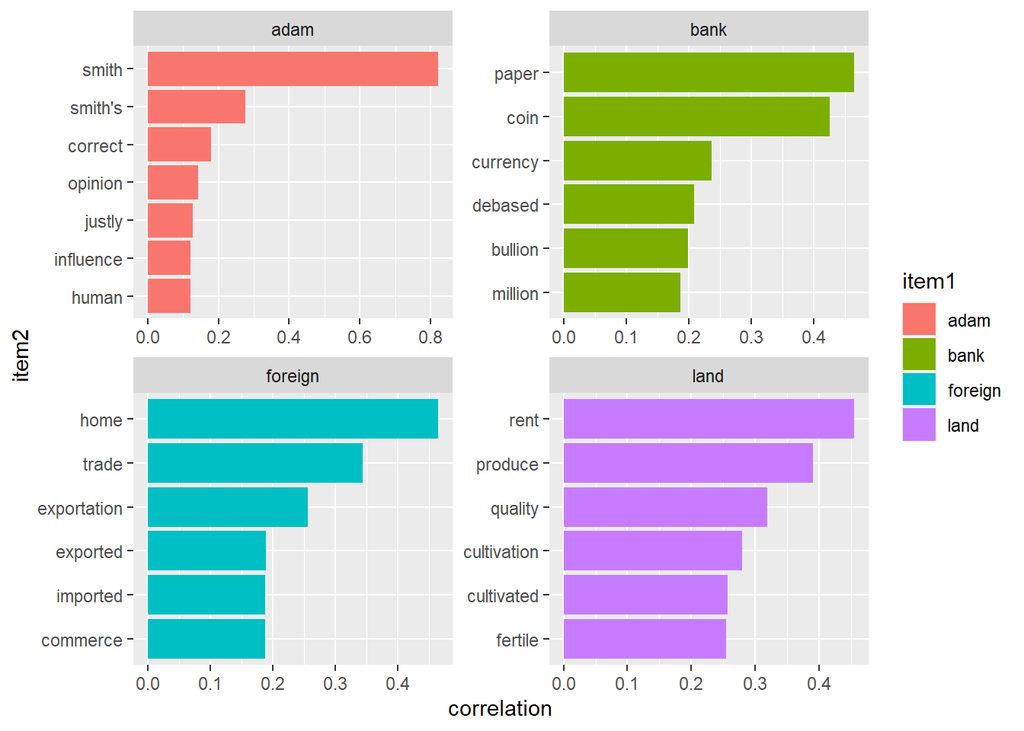

```r
ricardo_word_cors %>%
  filter(item1 %in% c("adam", "land", "foreign", "bank")) %>%
  group_by(item1) %>%
  slice_max(correlation, n = 6) %>%
  ungroup() %>%
  mutate(item2 = reorder(item2, correlation)) %>%
  ggplot(aes(item2, correlation, fill=item1)) +
  geom_bar(stat = "identity") +
  facet_wrap(~ item1, scales = "free") +
  coord_flip()
```

### Plotting correlations in a graph

For this last part, in the same way that I employed ggraph to represent bigrams visually, I used it to portray the connections and groups of words.

**Keynes**

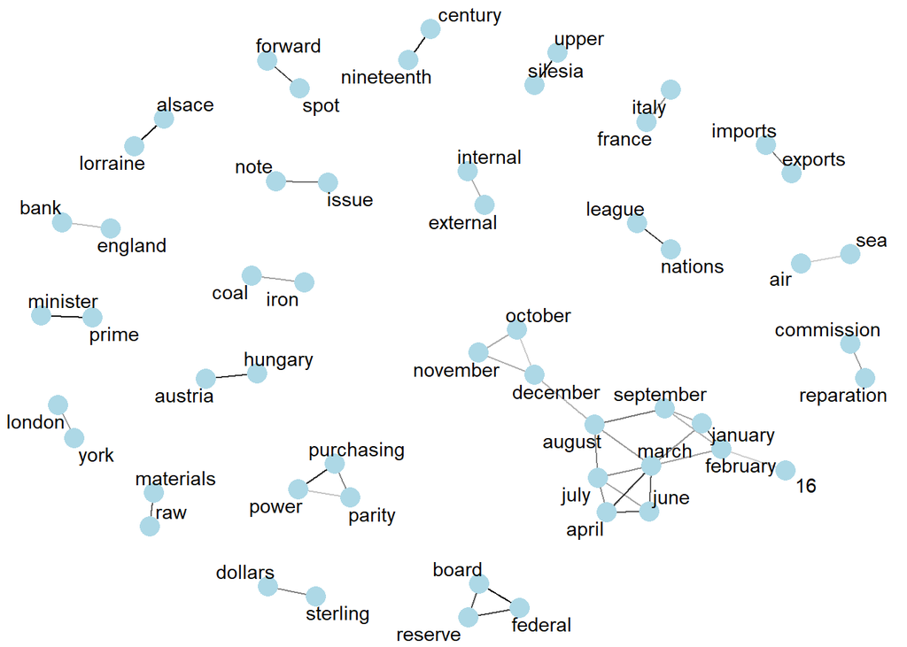

```r
keynes_word_cors %>%
  filter(correlation > 0.40) %>%
  graph_from_data_frame() %>%
  ggraph(layout = "fr") +
  geom_edge_link(aes(edge_alpha = correlation), show.legend = FALSE) +
  geom_node_point(color = "lightblue", size = 5) +
  geom_node_text(aes(label = name), repel = TRUE) +
  theme_void()
```

Highly correlated words can be observed in this graph and it can be seen a group of months, political terms, economic terms, currencies and values, and international issues.

**Smith**

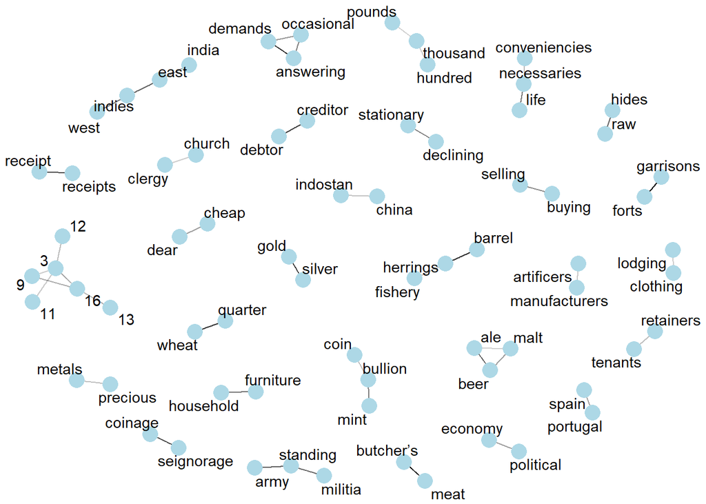

```r
smith_word_cors %>%
  filter(correlation > 0.45) %>%
  graph_from_data_frame() %>%
  ggraph(layout = "fr") +
  geom_edge_link(aes(edge_alpha = correlation), show.legend = FALSE) +
  geom_node_point(color = "lightblue", size = 5) +
  geom_node_text(aes(label = name), repel = TRUE) +
  theme_void()
```

For Smith, a group of words related to fish can be observed, financial terms, raw materials like precious metals, territories like India and Asia and other economic terms like demands, seignorage, selling, buying, stationary, etc.

**Ricardo**

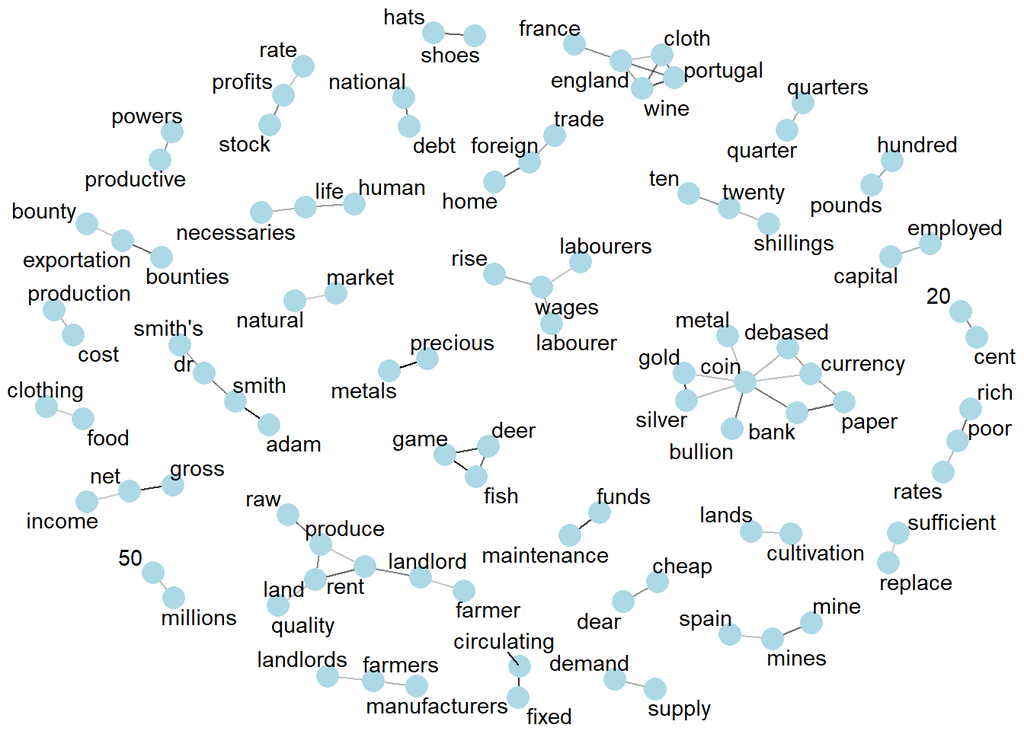

```r
ricardo_word_cors %>%
  filter(correlation > 0.30) %>%
  graph_from_data_frame() %>%
  ggraph(layout = "fr") +
  geom_edge_link(aes(edge_alpha = correlation), show.legend = FALSE) +
  geom_node_point(color = "lightblue", size = 5) +
  geom_node_text(aes(label = name), repel = TRUE) +
  theme_void()
```

For Ricardo, a lower threshold for correlation was used (0.30) which can be due to the more variety of words and concepts that he uses in his text. It can be seen that a big group of words around coin is created with connected words related to currencies and precious metals. Also a section of labor economics is seen with words like wages, laborers and rise. Places can also be seen, raw materials and finally there is an Adam Smith group.

## Conclusions

Looking at correlations between pairs of words, Keynes has high correlations for pairs such as “silesia upper”, “purchasing power”, and “league nations”, while for Smith the highest correlations are for pairs such as “butcher’s meat”, “forts garrisons”, and “silver gold”. For Ricardo, high correlations were found for pairs such as “Adam Smith”, “precious metals”, and “fish game”. It’s interesting to note that while all three economists were writing about economics, their frequently occurring words, pairs of words, and correlations differ. This suggests that they had different areas of focus and interest within the field of economics.